# Memory Retention following Acoustic Stimulation in Slow-Wave Sleep: A Meta-Analytic Review of Replicability and Measurement Quality

Matthew B Jané

2023-03-10

### Decline Effect: Set Up

Load in database from github

```r
library(metafor)
library(ggplot2)
library(dplyr)
library(ggbeeswarm)
library(readr)
library(gtable)
library(grid)
library(gridExtra)
library(dplyr)

urlfile="https://raw.githubusercontent.com/MatthewBJane/meta_analyses/main/acoustic_stimulation_and_memory/data/meta_analytic_data.csv"

df <- read_csv(url(urlfile))
```

# Effect Sizes and Decline Effect

### Calculate publication date

To calculate publication date, we used the year, month, and day of when the study was published online. Then we scale the publication date so that 0 indicates the date of the first publication.

```r
publication_date = df$year + (df$month)/12 + (df$day/30.437)/12
publication_date_scaled = publication_date - min(publication_date)

df = cbind(df,publication_date,publication_date_scaled)
```

### Calculating standardized mean differences

Standardized mean differences (SMD) using Glass’ formulation are used,

$\frac{M_{\text{stim}}-M_{\text{sham}}}{S_{\text{sham}}}$

This formulation is uses the standard deviation of the control (i.e., SHAM) condition as the standardizer. Variance ratio between STIM and SHAM is also calculated for each study to demonstrate violation of the equal variance assumption.

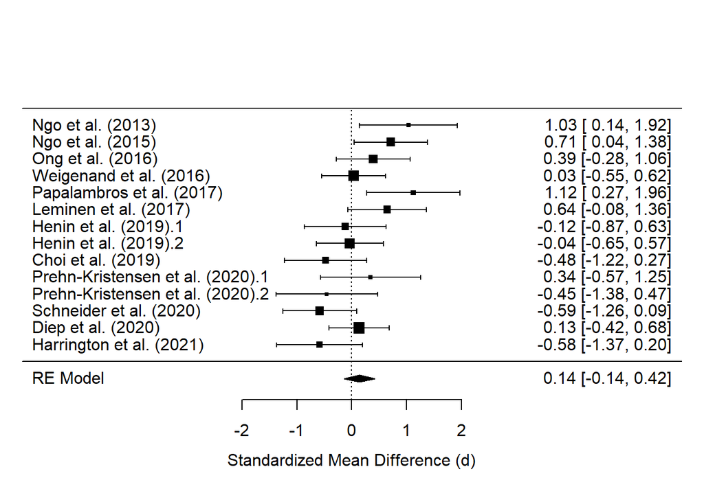

```r
n = df$eff_n
J = 1 - 3/(4*(n-1) - 1) # Hedges' Correction Factor

Mstim = df$Mstim # Mean of STIM condition
Msham = df$Msham # Mean of SHAM condition

SDstim = df$SDstim # Standard deviation of STIM condition
SDsham = df$SDsham # Standard deviation of SHAM condition

d = (Mstim - Msham) / SDsham # Standardized Mean difference (Glass' Delta)
v = 2/n + (d^2) / (2*(n - 1)) # Sampling Variance

d = d*J   # Applying correction factor to SMD
v = v*J^2 # Standardized Mean difference (Glass' Delta)

VarRatio = (SDstim^2) / (SDsham^2)  # Calculation of variance ratio between STIM and SHAM conditions

df = cbind(df,d,v,VarRatio)

forest(rma(data=df,yi=d,vi=v,method='REML',
           slab = paste(df$study,' (',df$year,')',sep = '')),
       alim = c(-2,2),
       xlim=c(-6,6),
       xlab = 'Standardized Mean Difference (d)')
```

### Replication of Wunderlin et al. (2021)

Replication of the effect sizes reported in Wunderlin and colleague’s meta-analysis.

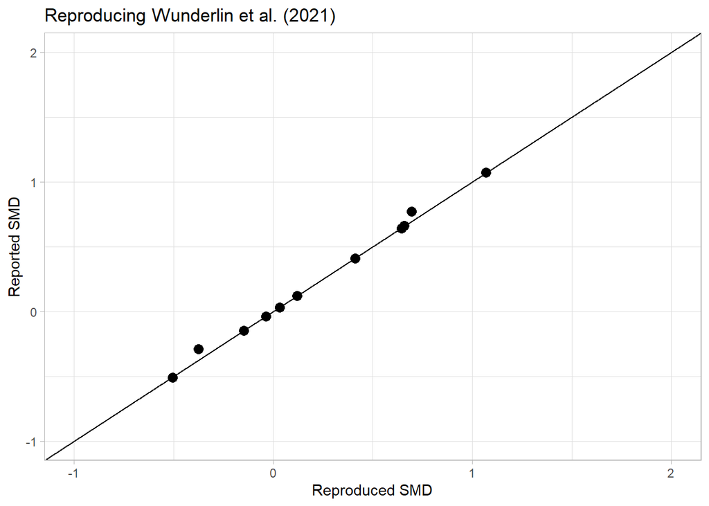

```r
r = df$r # Pearson correlation between stimulation and sham conditions
Zr = atanh(r) # Fisher's z-transformation of Pearson correlation
Zv = 1/(n-3)  # Fisher's z sampling variance
mdlr = rma(yi=Zr,vi=Zv) # Random-effects model of Fisher's z correlations
av_r = tanh(mdlr$beta) # back-transformed pooled Fisher's z to Pearson r
r[is.na(r)] = av_r # fill in missing correlations with meta-analytic estimate
SDdiff = sqrt(SDstim^2 + SDsham^2 - 2*r*SDstim*SDsham)  # Standard deviation of difference
SDwithin = SDdiff / sqrt(2*(1-r)) # Standard deviation within
d_rep = (Mstim - Msham) / SDwithin  # Standardized mean difference w/ small sample bias correction (Cohen's d)
v_rep = ( 1/n + (d_rep^2)/(2*n) ) * 2 * (1 - r) # sampling variance
d_wunderlin_rep = d_rep * J
v_wunderlin_rep = v_rep * J^2

df = cbind(df,d_wunderlin_rep)

ggplot(data = df,aes(x=d_wunderlin_rep,y=d_wunderlin))+
  geom_point(size=3)+
  geom_abline(slope = 1,intercept = 0)+
  xlim(-1,2)+
  ylim(-1,2)+
  theme_light()+
  xlab('Reproduced SMD')+
  ylab('Reported SMD')+
  ggtitle('Reproducing Wunderlin et al. (2021)')
```

### Replication of Stanyer et al. (2022)

Replication of the effect sizes reported in Stanyer and colleague’s meta-analysis.

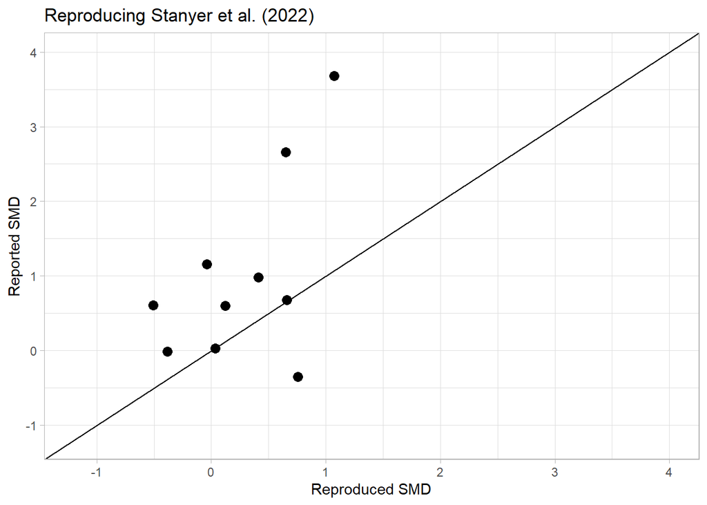

```r
n = df$eff_n
Mstim = df$Mstim # Mean of STIM condition
Msham = df$Msham # Mean of SHAM condition
SDstim = df$SDstim # Standard deviation of STIM condition
SDsham = df$SDsham # Standard deviation of SHAM condition
d_rep = (Mstim - Msham) / sqrt((SDsham^2 + SDstim^2)/2) # Standardized Mean difference
v_rep = (2*n)/(n^2) + (d_rep^2) / (n - 2)
d_stanyer_rep = d_rep*J
v_stanyer_rep = v_rep*J^2

df = cbind(df,d_stanyer_rep)

ggplot(data = df,aes(x=d_stanyer_rep,y=d_stanyer))+
  geom_point(size=3)+
  geom_abline(slope = 1,intercept = 0)+
  xlim(-1.2,4)+
  ylim(-1.2,4)+
  theme_light()+
  xlab('Reproduced SMD')+
  ylab('Reported SMD')+
  ggtitle('Reproducing Stanyer et al. (2022)')
```

### Decline Effect: Publication date as a moderator of SMDs

Publication date is assessed as a moderator of the observed SMDs. Scaled model is reported in table the manuscript

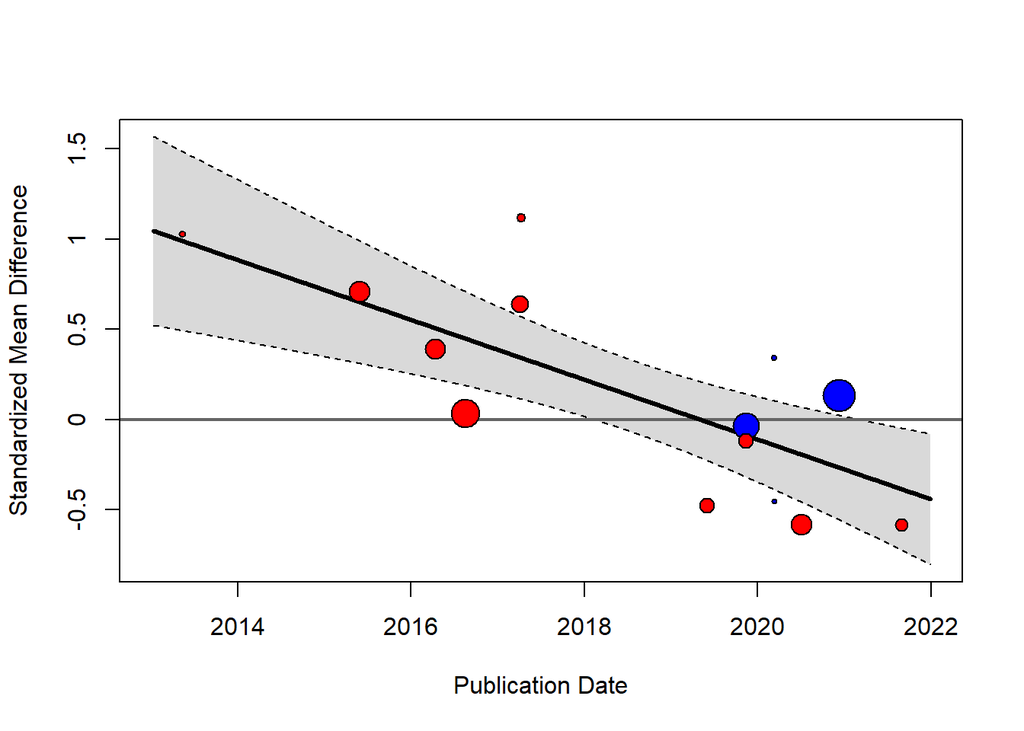

```r
base_model1 = rma(data=df, yi = d, vi = v, mods = ~  publication_date, method = 'REML', slab = study)
base_model1_scaled = rma(data=df, yi = d, vi = v, mods = ~  publication_date_scaled, method = 'REML', slab = study)

blinding_color = c()
blinding_color[df$blinding=='Single'] = 'red'
blinding_color[df$blinding=='Double'] = 'blue'

regplot(base_model1,
        ylab = 'Standardized Mean Difference',
        xlab = 'Publication Date',
        xlim =c(2013,2022),
        refline = 0,
        bg = blinding_color)
```

### Decline Effect: Leave-One-Out Cross Validation (LOOCV) to check model robustness

Using LOOCV, we can iteratively leave one effect size out at a time then fit the remaining effect sizes to the above meta-regression model to see if regression parameter estimates are sensitive to individual studies. The regression coefficients (w/ 95% CI) are plotted for each iteration of the LOOCV.

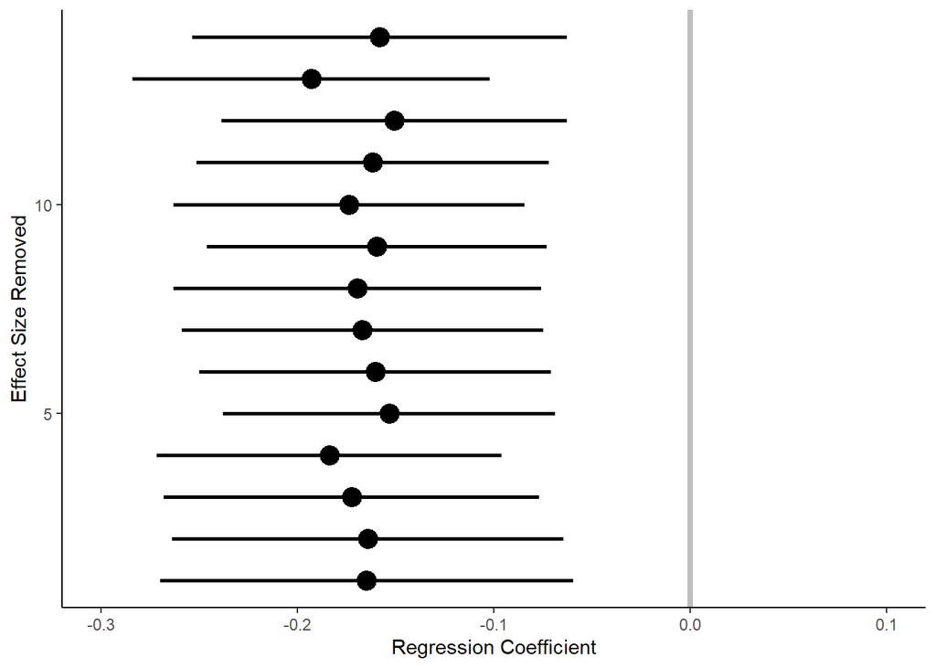

```r
LOOCV_est = c()
LOOCV_est_LCI = c()
LOOCV_est_UCI = c()
for(i in 1:nrow(df)){

  CVmodel1 = rma(data=df, yi = d, vi = v, mods = ~  publication_date, method = 'REML',subset = !(1:nrow(df) %in% i))
  LOOCV_est[i] = CVmodel1$beta[2]
  LOOCV_est_LCI[i] = CVmodel1$ci.lb[2]
  LOOCV_est_UCI[i] = CVmodel1$ci.ub[2]

}

ggplot(data=NULL,aes(x=LOOCV_est,y=1:nrow(df)))+
  geom_pointrange(aes(xmin=LOOCV_est_LCI,xmax=LOOCV_est_UCI),lwd=1,size=1)+
  xlim(-.3,.1) +
  theme_classic()+
  geom_vline(xintercept=0,color='grey',lwd=1.5) +
  xlab('Regression Coefficient')+
  ylab('Effect Size Removed')
```

### Alternative study-level moderators

Other study-level moderators that may account for this decline effect. Models consist of publication date + one other study-level characteristics.

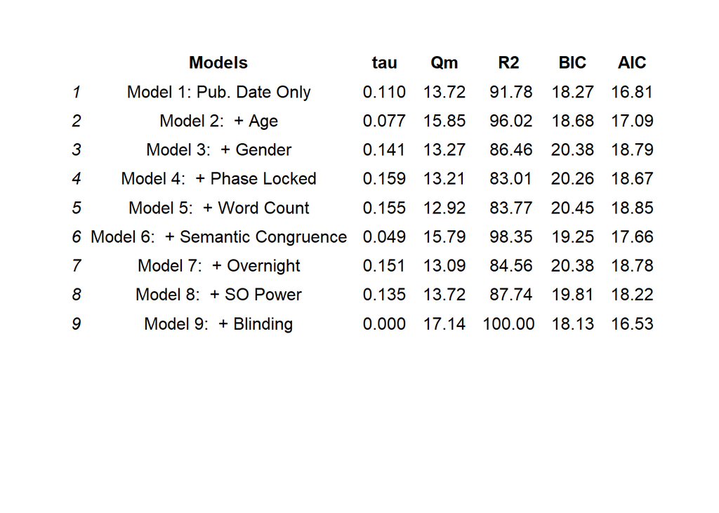

```r
# alternative study models
alt_model2 = rma(data=df, yi = d, vi = v, mods = ~ publication_date_scaled + age         , method = 'REML')
alt_model3 = rma(data=df, yi = d, vi = v, mods = ~ publication_date_scaled + pfem        , method = 'REML')
alt_model4 = rma(data=df, yi = d, vi = v, mods = ~ publication_date_scaled + closed_loop , method = 'REML')
alt_model5 = rma(data=df, yi = d, vi = v, mods = ~ publication_date_scaled + word_count  , method = 'REML')
alt_model6 = rma(data=df, yi = d, vi = v, mods = ~ publication_date_scaled + semantic    , method = 'REML')
alt_model7 = rma(data=df, yi = d, vi = v, mods = ~ publication_date_scaled + whole_night , method = 'REML')
alt_model8 = rma(data=df, yi = d, vi = v, mods = ~ publication_date_scaled + so_power    , method = 'REML')
alt_model9 = rma(data=df, yi = d, vi = v, mods = ~ publication_date_scaled + factor(blinding)    , method = 'REML')

# Table of fit statistics
model_table = data.frame(
Models = c('Model 1: Pub. Date Only', 'Model 2:  + Age','Model 3:  + Gender','Model 4:  + Phase Locked','Model 5:  + Word Count','Model 6:  + Semantic Congruence','Model 7:  + Overnight','Model 8:  + SO Power','Model 9:  + Blinding'),
tau = round(c(sqrt(base_model1_scaled$tau2),sqrt(alt_model2$tau2),sqrt(alt_model3$tau2),sqrt(alt_model4$tau2),sqrt(alt_model5$tau2),sqrt(alt_model6$tau2),sqrt(alt_model7$tau2),sqrt(alt_model8$tau2),sqrt(alt_model9$tau2)),3),
Qm = round(c(base_model1_scaled$QM,alt_model2$QM,alt_model3$QM,alt_model4$QM,alt_model5$QM,alt_model6$QM,alt_model7$QM,alt_model8$QM,alt_model9$QM),2),
R2 = round(c(base_model1_scaled$R2,alt_model2$R2,alt_model3$R2,alt_model4$R2,alt_model5$R2,alt_model6$R2,alt_model7$R2,alt_model8$R2,alt_model9$R2),2),
BIC = round(BIC.rma(base_model1_scaled,alt_model2,alt_model3,alt_model4,alt_model5,alt_model6,alt_model7,alt_model8,alt_model9)[,2],2),
AIC = round(AIC.rma(base_model1_scaled,alt_model2,alt_model3,alt_model4,alt_model5,alt_model6,alt_model7,alt_model8,alt_model9)[,2],2)
)

mt <- tableGrob(model_table,theme = ttheme_minimal())

grid.arrange(mt, heights = c(3,1))
```

# Reliability Analysis

### Set up

Load in raw data from available studies on Github

```r
urlfile="https://raw.githubusercontent.com/MatthewBJane/meta_analyses/main/acoustic_stimulation_and_memory/data/individual_person_data.csv"

df_rel <- read_csv(url(urlfile))
```

### Calculation

Calculate correlations between pre and post-sleep scores as well as reliability coefficients for pre-sleep, post-sleep, and difference scores. Reliability of difference scores are calculated with the following equation:

$\rho_d = \frac{\rho_{\text{pre}}+\rho_{\text{post}}-2 r_{\text{pp}}}{2(1-r_{\text{pp}})}$

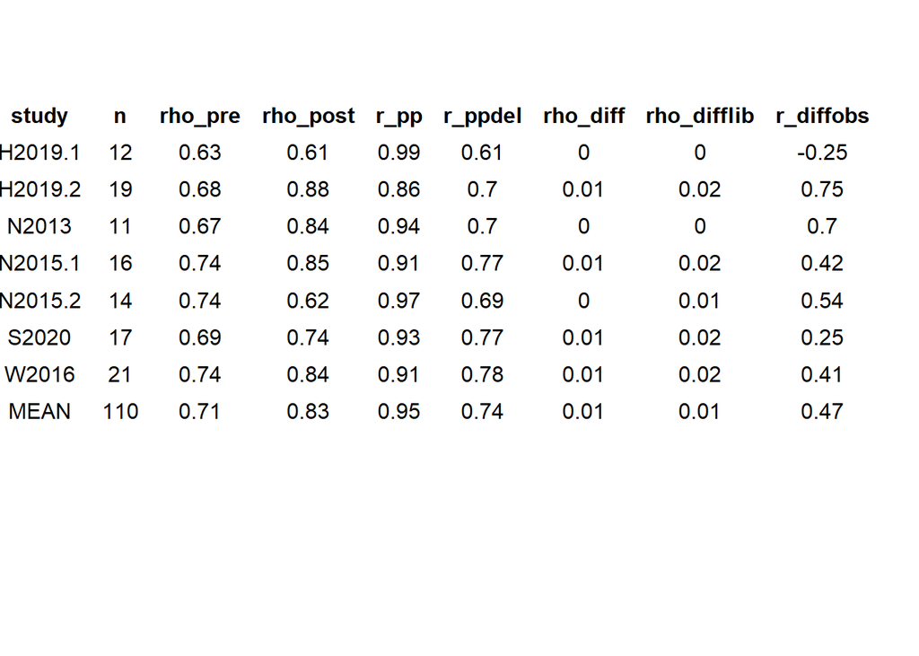

```r
# Create data frame of reliability coefficients for each study
REL = df_rel %>%
  group_by(study) %>%
  summarize(n = length(study),
            rho_pre=round(cor(preSham, preStim),2),
            rho_post=round(cor(postSham, postStim),2),
            r_pp=round(cor(preSham, postSham),2),
            r_ppdel=round(cor(postSham, preStim),2),
            rho_diff = round((cor(preSham, preStim) + cor(postSham, postStim) - 2*cor(preSham, postStim)) / 2*(1-cor(preSham, postSham)),2),
            rho_difflib= round((cor(preSham, preStim) + cor(postSham, postStim) - 2*cor(preSham, postStim)) / 2*(1-cor(preStim, postSham)),2),
            r_diffobs = round(cor(postStim-preStim, postSham-preSham),2)
            )

# Synthesize reliability coefficients
reliability = rbind(REL,
  c("MEAN",
    sum(REL$n),
    round(rma(data=REL,ri=rho_pre,ni=n,measure = 'COR')$beta,2),
    round(rma(data=REL,ri=rho_post,ni=n,measure = 'COR')$beta,2),
    round(rma(data=REL,ri=r_pp,ni=n,measure = 'COR')$beta,2),
    round(rma(data=REL,ri=r_ppdel,ni=n,measure = 'COR')$beta,2),
    round(rma(data=REL,ri=rho_diff,ni=n,measure = 'COR')$beta,2),
    round(rma(data=REL,ri=rho_difflib,ni=n,measure = 'COR')$beta,2),
    round(rma(data=REL,ri=r_diffobs,ni=n,measure = 'COR')$beta,2)
  )
)

tt <- tableGrob(reliability,theme = ttheme_minimal())

grid.arrange(tt,heights=c(4,1),widths = c(10,1))
```

### Inflation of False Discovery with Measurement Error

$d_{obs} = d_{true}\sqrt{\rho_d}$

[figure not shown]

```r
# Assign parameters (sample size = 20)
n = 20
d_true = 0
se_no_error = sqrt((2*n)/(n^2))
FD_thresh = 1.96*se_no_error
rho = seq(.01,.99,length.out= 100)


# Calculate false discovery rate as a function of reliability
FDrate = c()
for(i in 1:length(rho)){

se_obs = se_no_error/sqrt(rho[i])
FDrate[i] = 1-pnorm(FD_thresh,mean = 0,sd=se_obs)

}

# Plot false discovery rate as a function of reliability
ggplot(data=NULL,aes(x=rho,y=FDrate))+
  geom_line(lwd=1.5,color='gray') +
  xlab('Reliability ') +
  ylab('False Discovery Rate (2-tailed)') +
  theme_classic()
```

### Biasing of SMDs when Measurement Error is present

Visualizing the biasing of SMDs when measurement error is present. The biasing of SMD is a function of the true effect size and the reliability of the measure $d_{obs} = d_{true}\sqrt{\rho_d}$. Here we demonstrate the biasing effect of reliability with different true effect sizes

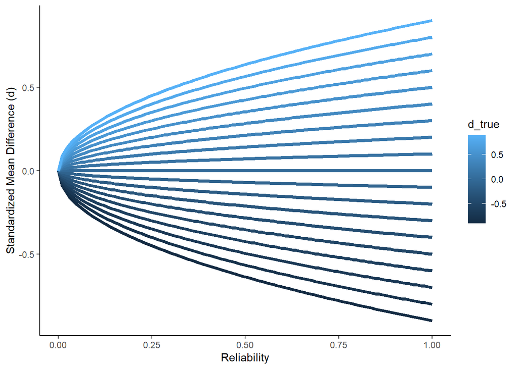

```r
# Define various levels of true SMDs
rho = rep(seq(0,1,length.out=100),19)
d_true = c(rep(.1,100),rep(.2,100),rep(.3,100),rep(.4,100),rep(.5,100),rep(.6,100),rep(.7,100),rep(.8,100),rep(.9,100),rep(0,100),
           rep(-.1,100),rep(-.2,100),rep(-.3,100),rep(-.4,100),rep(-.5,100),rep(-.6,100),rep(-.7,100),rep(-.8,100),rep(-.9,100))

# Calculate observed SMDs as a function of reliability
d_obs = d_true*sqrt(rho)

# Plot out observed SMDs as a function of reliability
ggplot(data=NULL,aes(x=rho,y=d_obs,group=d_true,color=d_true))+
  geom_line(lwd=1.5) +
  xlab('Reliability') +
  ylab('Standardized Mean Difference (d)') +
  theme_classic()
```